# Population Growth and CO2 Emissions

MWIZERWA Jacques

2026-11-04

# 0.1 Abstract

This project looks at how population size is related to carbon dioxide (CO₂) emissions using two datasets: World Population and CO₂ Emissions. It involves checking and cleaning the data, estimating population in 2030, creating graphs to show population and CO₂ trends, and examining relationships between the variables.

The population dataset contains 234 countries and territories, while the CO₂ dataset contains 215 country records. Not all countries could be matched between the two datasets because of differences in country names and missing data.

It is important to note that CO₂ emissions are measured per person (metric tons per capita), not as each country’s total emissions. Therefore, the results show relationships involving emissions per person rather than total CO₂ output

# 1. Introduction

Population growth can increase the need for energy, transport, goods and other resources. These activities can contribute to CO₂ emissions. However, emissions also depend on how countries produce energy, their economic activities, technology and people’s lifestyles.

This project aims to study population trends and find out whether countries with larger populations also tend to have higher CO₂ emissions.

# 2. Methods and dataset

# 3. Load packages and data preparation

```r
library(tidyverse)   # dplyr, ggplot2, tidyr, readr
library(scales)      # nicer axis labels

pop <- read.csv("C:/Users/HP/Documents/BigDataR/Mid-term exam 2026 big data/world_population.csv",
                check.names = FALSE)
co2 <- read.csv("C:/Users/HP/Documents/BigDataR/Mid-term exam 2026 big data/CO2_emission.csv",
                check.names = FALSE)
```

## 3.1 Column names of both datasets

```r
names(pop)
```

```
##  [1] "Rank"                        "CCA3"
##  [3] "Country/Territory"           "Capital"
##  [5] "Continent"                   "2022 Population"
##  [7] "2020 Population"             "2015 Population"
##  [9] "2010 Population"             "2000 Population"
## [11] "1990 Population"             "1980 Population"
## [13] "1970 Population"             "Area (km²)"
## [15] "Density (per km²)"           "Growth Rate"
## [17] "World Population Percentage"
```

```r
names(co2)
```

```
##  [1] "Country Name"   "country_code"   "Region"         "Indicator Name"
##  [5] "1990"           "1991"           "1992"           "1993"
##  [9] "1994"           "1995"           "1996"           "1997"
## [13] "1998"           "1999"           "2000"           "2001"
## [17] "2002"           "2003"           "2004"           "2005"
## [21] "2006"           "2007"           "2008"           "2009"
## [25] "2010"           "2011"           "2012"           "2013"
## [29] "2014"           "2015"           "2016"           "2017"
## [33] "2018"           "2019"           "2019"
```

# 3.2 Exploratory data analysis (population dataset)

```r
names(pop)          # variable names
```

```
##  [1] "Rank"                        "CCA3"
##  [3] "Country/Territory"           "Capital"
##  [5] "Continent"                   "2022 Population"
##  [7] "2020 Population"             "2015 Population"
##  [9] "2010 Population"             "2000 Population"
## [11] "1990 Population"             "1980 Population"
## [13] "1970 Population"             "Area (km²)"
## [15] "Density (per km²)"           "Growth Rate"
## [17] "World Population Percentage"
```

```r
head(pop, 5)        # top 5 rows
```

```
##   Rank CCA3 Country/Territory          Capital Continent 2022 Population
## 1   36  AFG       Afghanistan            Kabul      Asia        41128771
## 2  138  ALB           Albania           Tirana    Europe         2842321
## 3   34  DZA           Algeria          Algiers    Africa        44903225
## 4  213  ASM    American Samoa        Pago Pago   Oceania           44273
## 5  203  AND           Andorra Andorra la Vella    Europe           79824
##   2020 Population 2015 Population 2010 Population 2000 Population
## 1        38972230        33753499        28189672        19542982
## 2         2866849         2882481         2913399         3182021
## 3        43451666        39543154        35856344        30774621
## 4           46189           51368           54849           58230
## 5           77700           71746           71519           66097
##   1990 Population 1980 Population 1970 Population Area (km²) Density (per km²)
## 1        10694796        12486631        10752971     652230           63.0587
## 2         3295066         2941651         2324731      28748           98.8702
## 3        25518074        18739378        13795915    2381741           18.8531
## 4           47818           32886           27075        199          222.4774
## 5           53569           35611           19860        468          170.5641
##   Growth Rate World Population Percentage
## 1      1.0257                        0.52
## 2      0.9957                        0.04
## 3      1.0164                        0.56
## 4      0.9831                        0.00
## 5      1.0100                        0.00
```

```r
tail(pop, 10)       # bottom 10 rows
```

```
##     Rank CCA3 Country/Territory      Capital     Continent 2022 Population
## 225   43  UZB        Uzbekistan     Tashkent          Asia        34627652
## 226  181  VUT           Vanuatu    Port-Vila       Oceania          326740
## 227  234  VAT      Vatican City Vatican City        Europe             510
## 228   51  VEN         Venezuela      Caracas South America        28301696
## 229   16  VNM           Vietnam        Hanoi          Asia        98186856
## 230  226  WLF Wallis and Futuna     Mata-Utu       Oceania           11572
## 231  172  ESH    Western Sahara     El Aaiún        Africa          575986
## 232   46  YEM             Yemen        Sanaa          Asia        33696614
## 233   63  ZMB            Zambia       Lusaka        Africa        20017675
## 234   74  ZWE          Zimbabwe       Harare        Africa        16320537
##     2020 Population 2015 Population 2010 Population 2000 Population
## 225        33526656        30949417        28614227        24925554
## 226          311685          276438          245453          192074
## 227             520             564             596             651
```

[output cut: 29 more lines]

```r
str(pop)            # data types
```

```
## 'data.frame':    234 obs. of  17 variables:
##  $ Rank                       : int  36 138 34 213 203 42 224 201 33 140 ...
##  $ CCA3                       : chr  "AFG" "ALB" "DZA" "ASM" ...
##  $ Country/Territory          : chr  "Afghanistan" "Albania" "Algeria" "American Samoa" ...
##  $ Capital                    : chr  "Kabul" "Tirana" "Algiers" "Pago Pago" ...
##  $ Continent                  : chr  "Asia" "Europe" "Africa" "Oceania" ...
##  $ 2022 Population            : int  41128771 2842321 44903225 44273 79824 35588987 15857 93763 45510318 2780469 ...
##  $ 2020 Population            : int  38972230 2866849 43451666 46189 77700 33428485 15585 92664 45036032 2805608 ...
##  $ 2015 Population            : int  33753499 2882481 39543154 51368 71746 28127721 14525 89941 43257065 2878595 ...
##  $ 2010 Population            : int  28189672 2913399 35856344 54849 71519 23364185 13172 85695 41100123 2946293 ...
##  $ 2000 Population            : int  19542982 3182021 30774621 58230 66097 16394062 11047 75055 37070774 3168523 ...
##  $ 1990 Population            : int  10694796 3295066 25518074 47818 53569 11828638 8316 63328 32637657 3556539 ...
##  $ 1980 Population            : int  12486631 2941651 18739378 32886 35611 8330047 6560 64888 28024803 3135123 ...
##  $ 1970 Population            : int  10752971 2324731 13795915 27075 19860 6029700 6283 64516 23842803 2534377 ...
##  $ Area (km²)                 : int  652230 28748 2381741 199 468 1246700 91 442 2780400 29743 ...
##  $ Density (per km²)          : num  63.1 98.9 18.9 222.5 170.6 ...
##  $ Growth Rate                : num  1.026 0.996 1.016 0.983 1.01 ...
##  $ World Population Percentage: num  0.52 0.04 0.56 0 0 0.45 0 0 0.57 0.03 ...
```

```r
dim(pop)            # shape: rows and columns
```

```
## [1] 234  17
```

## 3.3 Duplicates

```r
sum(duplicated(pop))        # how many duplicate rows
```

```
## [1] 0
```

```r
pop <- distinct(pop)        # drop them (if any)
dim(pop)
```

```
## [1] 234  17
```

## 3.4 Missing values

```r
colSums(is.na(pop))
```

```
##                        Rank                        CCA3
##                           0                           0
##           Country/Territory                     Capital
##                           0                           0
##                   Continent             2022 Population
##                           0                           0
##             2020 Population             2015 Population
##                           0                           0
##             2010 Population             2000 Population
##                           0                           0
##             1990 Population             1980 Population
##                           0                           0
##             1970 Population                  Area (km²)
##                           0                           0
##           Density (per km²)                 Growth Rate
##                           0                           0
## World Population Percentage
##                           0
```

Method used: numeric columns are filled with the **median** (the median is not pulled by very big countries like China and India); text columns are filled with “Unknown”.

```r
pop <- pop %>%
  mutate(across(where(is.numeric), ~ ifelse(is.na(.x), median(.x, na.rm = TRUE), .x))) %>%
  mutate(across(where(is.character), ~ ifelse(is.na(.x) | .x == "", "Unknown", .x)))

colSums(is.na(pop))   # should be all 0 now
```

```
##                        Rank                        CCA3
##                           0                           0
##           Country/Territory                     Capital
##                           0                           0
##                   Continent             2022 Population
##                           0                           0
##             2020 Population             2015 Population
##                           0                           0
##             2010 Population             2000 Population
##                           0                           0
##             1990 Population             1980 Population
##                           0                           0
##             1970 Population                  Area (km²)
##                           0                           0
##           Density (per km²)                 Growth Rate
##                           0                           0
## World Population Percentage
##                           0
```

## 3.5 Outliers (box plots)

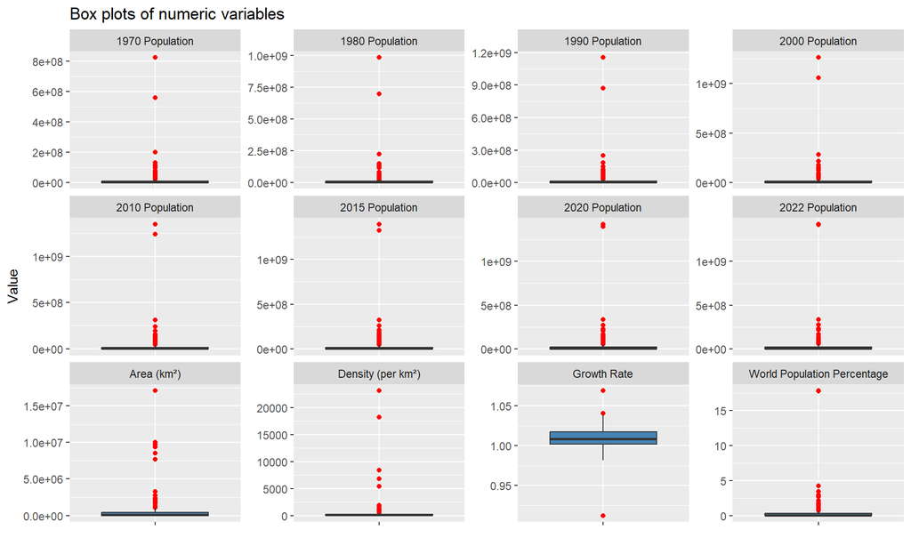

```r
num_vars <- pop %>% select(where(is.numeric)) %>% select(-any_of("Rank"))

num_vars %>%
  pivot_longer(everything(), names_to = "variable", values_to = "value") %>%
  ggplot(aes(x = "", y = value)) +
  geom_boxplot(fill = "steelblue", outlier.color = "red") +
  facet_wrap(~ variable, scales = "free_y") +
  labs(x = NULL, y = "Value", title = "Box plots of numeric variables")
```

## 3.5.1 Number of outliers per variable (IQR rule)

```r
count_outliers <- function(x) {
  q <- quantile(x, c(.25, .75), na.rm = TRUE)
  iqr <- q[2] - q[1]
  sum(x < q[1] - 1.5 * iqr | x > q[2] + 1.5 * iqr)
}
sapply(num_vars, count_outliers)
```

```
##             2022 Population             2020 Population
##                          25                          26
##             2015 Population             2010 Population
##                          27                          26
##             2000 Population             1990 Population
##                          29                          31
##             1980 Population             1970 Population
##                          32                          29
##                  Area (km²)           Density (per km²)
##                          28                          22
##                 Growth Rate World Population Percentage
##                           3                          25
```

**Decision.** Most outliers here are real countries (China, India, Monaco, Macau…), not mistakes, so I do **not delete** them. I keep the real values for the rankings and the projections. For the correlation work I make a *capped* copy (winsorising at the 1.5 x IQR limits) so extreme values do not dominate.

```r
cap_iqr <- function(x) {
  q <- quantile(x, c(.25, .75), na.rm = TRUE)
  iqr <- q[2] - q[1]
  pmin(pmax(x, q[1] - 1.5 * iqr), q[2] + 1.5 * iqr)
}

pop_capped <- pop
cols_to_cap <- c("Density (per km²)", "Growth Rate", "World Population Percentage", "Area (km²)")
cols_to_cap <- intersect(cols_to_cap, names(pop))
pop_capped[cols_to_cap] <- lapply(pop[cols_to_cap], cap_iqr)
```

# 4. New variable: population in 2030

Formula: $N_t = P e^{rt}$ with P = population in 2022 and t = 2030 - 2022 = 8 years.

In this dataset *Growth Rate* is a yearly multiplier (for example 1.0027 means +0.27% per year). So the continuous rate is $r = \ln(\text{Growth Rate})$.

```r
pop <- pop %>%
  mutate(
    r = log(`Growth Rate`),
    t = 2030 - 2022,
    Pop_2030 = `2022 Population` * exp(r * t)
  )

pop %>%
  select(`Country/Territory`, `2022 Population`, `Growth Rate`, Pop_2030) %>%
  mutate(Pop_2030 = round(Pop_2030)) %>%
  head(10)
```

```
##      Country/Territory 2022 Population Growth Rate Pop_2030
## 1          Afghanistan        41128771      1.0257 50385848
## 2              Albania         2842321      0.9957  2746004
## 3              Algeria        44903225      1.0164 51144011
## 4       American Samoa           44273      0.9831    38630
## 5              Andorra           79824      1.0100    86438
## 6               Angola        35588987      1.0315 45610989
## 7             Anguilla           15857      1.0066    16714
## 8  Antigua and Barbuda           93763      1.0058    98203
## 9            Argentina        45510318      1.0052 47438365
## 10             Armenia         2780469      0.9962  2697058
```

# 5. Top ten countries

## 5.1 Top 10 in 2022

```r
top10 <- pop %>%
  arrange(desc(`2022 Population`)) %>%
  slice_head(n = 10)

top10$`Country/Territory`
```

```
##  [1] "China"         "India"         "United States" "Indonesia"
##  [5] "Pakistan"      "Nigeria"       "Brazil"        "Bangladesh"
##  [9] "Russia"        "Mexico"
```

## 6. Data visualization

## 6.1 Graphs

**Graph 1: bar chart of 2022 population**

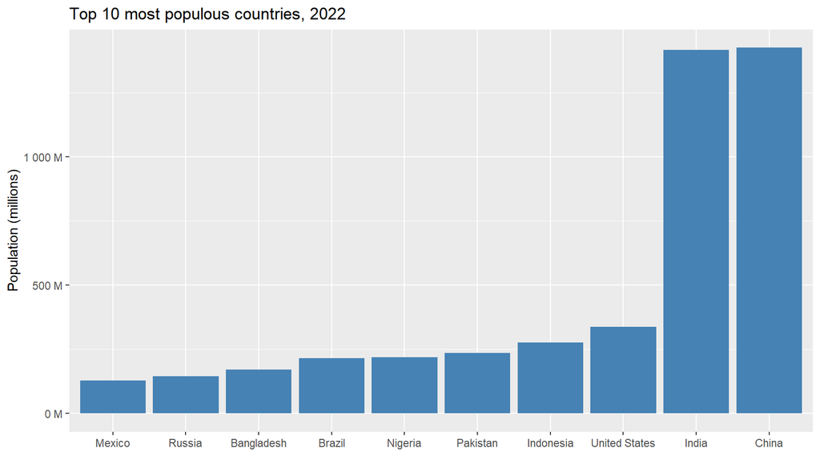

```r
ggplot(top10, aes(x = reorder(`Country/Territory`, `2022 Population`),
                  y = `2022 Population`)) +
  geom_col(fill = "steelblue") +
  scale_y_continuous(labels = label_number(scale = 1e-6, suffix = " M")) +
  labs(x = NULL, y = "Population (millions)",
       title = "Top 10 most populous countries, 2022")
```

**Graph 2: population trend 1990 to 2022 (line chart)**

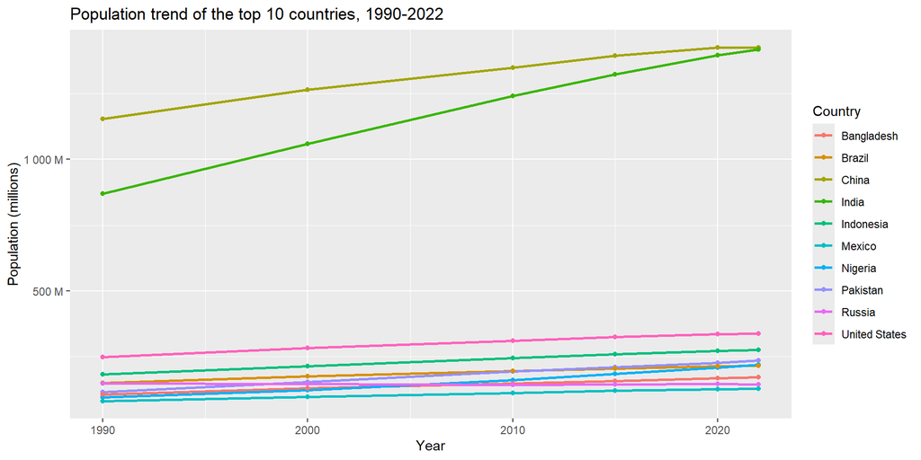

```r
year_cols <- c("1990 Population", "2000 Population", "2010 Population",
               "2015 Population", "2020 Population", "2022 Population")

trend <- top10 %>%
  select(`Country/Territory`, all_of(year_cols)) %>%
  pivot_longer(-`Country/Territory`, names_to = "Year", values_to = "Population") %>%
  mutate(Year = as.numeric(substr(Year, 1, 4)))

ggplot(trend, aes(x = Year, y = Population, colour = `Country/Territory`)) +
  geom_line(linewidth = 1) +
  geom_point() +
  scale_y_continuous(labels = label_number(scale = 1e-6, suffix = " M")) +
  labs(x = "Year", y = "Population (millions)", colour = "Country",
       title = "Population trend of the top 10 countries, 1990-2022")
```

**Graph 3: CO2 emission trend 1990 to 2019**

The CO2 file has one column per year, and the year 2019 appears twice. I first make the column names unique, then reshape to long format, and finally average the duplicated 2019 values so that each country has one value per year.

```r
names(co2) <- make.unique(names(co2))     # the repeated "2019" becomes "2019.1"

country_col   <- intersect(c("Country Name", "Country", "Country/Territory"), names(co2))[1]
year_cols_co2 <- names(co2)[grepl("^(19|20)[0-9]{2}", names(co2))]

co2_long <- co2 %>%
  select(all_of(country_col), all_of(year_cols_co2)) %>%
  rename(Country = all_of(country_col)) %>%
  pivot_longer(-Country, names_to = "Year", values_to = "CO2") %>%
  mutate(Year = as.numeric(substr(Year, 1, 4)), CO2 = as.numeric(CO2)) %>%
  filter(Year >= 1990, Year <= 2019) %>%
  group_by(Country, Year) %>%
  summarise(CO2 = mean(CO2, na.rm = TRUE), .groups = "drop") %>%
  mutate(CO2 = ifelse(is.nan(CO2), NA, CO2))
```

Country names are written differently in the two files (for example “Russia” and “Russian Federation”), so I make them the same before joining.

```r
co2_long <- co2_long %>%
  mutate(Country = recode(Country,
    "Russian Federation" = "Russia",
    "Egypt, Arab Rep."   = "Egypt",
    "Iran, Islamic Rep." = "Iran",
    "Korea, Rep."        = "South Korea",
    "Viet Nam"           = "Vietnam",
    "Turkiye"            = "Turkey"))

# Top-10 countries that still do not match (should be empty)
setdiff(top10$`Country/Territory`, unique(co2_long$Country))
```

```
## character(0)
```

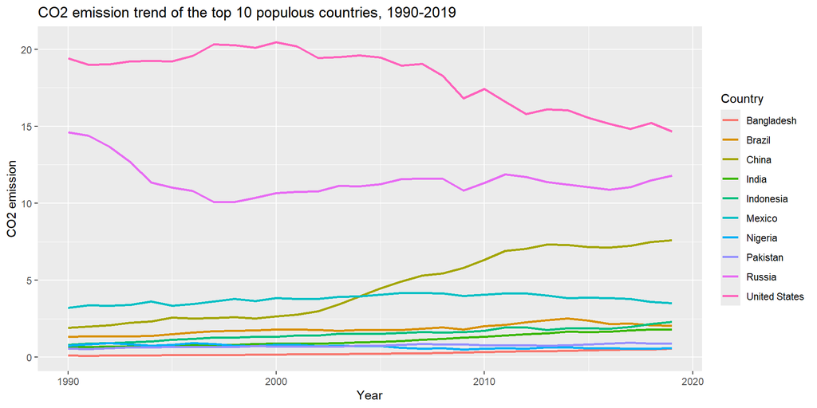

```r
co2_top10 <- co2_long %>% filter(Country %in% top10$`Country/Territory`)

ggplot(co2_top10, aes(x = Year, y = CO2, colour = Country)) +
  geom_line(linewidth = 1) +
  labs(x = "Year", y = "CO2 emission", colour = "Country",
       title = "CO2 emission trend of the top 10 populous countries, 1990-2019")
```

# 7. Correlation analysis

## Part 1: Area, Density, Growth rate, World population percentage

The capped data (`pop_capped`) is used so that extreme countries do not dominate the results.

```r
vars <- c("Area (km²)", "Density (per km²)", "Growth Rate", "World Population Percentage")
vars <- intersect(vars, names(pop_capped))

cor_mat <- cor(pop_capped[vars], use = "complete.obs", method = "pearson")
round(cor_mat, 2)
```

```
##                             Area (km²) Density (per km²) Growth Rate
## Area (km²)                        1.00             -0.41        0.28
## Density (per km²)                -0.41              1.00       -0.20
## Growth Rate                       0.28             -0.20        1.00
## World Population Percentage       0.70             -0.13        0.18
##                             World Population Percentage
## Area (km²)                                         0.70
## Density (per km²)                                 -0.13
## Growth Rate                                        0.18
## World Population Percentage                        1.00
```

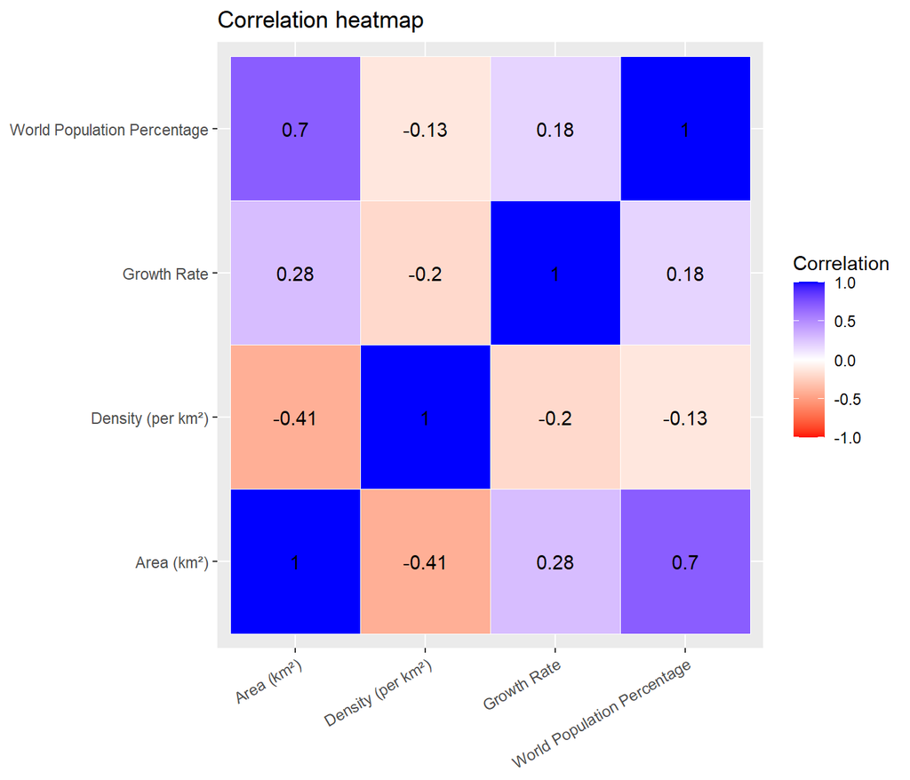

```r
# Heatmap with ggplot2
cor_mat %>%
  as.data.frame() %>%
  rownames_to_column("Var1") %>%
  pivot_longer(-Var1, names_to = "Var2", values_to = "Correlation") %>%
  ggplot(aes(Var1, Var2, fill = Correlation)) +
  geom_tile(colour = "white") +
  geom_text(aes(label = round(Correlation, 2))) +
  scale_fill_gradient2(low = "red", mid = "white", high = "blue", limits = c(-1, 1)) +
  labs(x = NULL, y = NULL, title = "Correlation heatmap") +
  theme(axis.text.x = element_text(angle = 30, hjust = 1))
```

Spearman correlation (based on ranks) as a second check:

```r
round(cor(pop_capped[vars], use = "complete.obs", method = "spearman"), 2)
```

```
##                             Area (km²) Density (per km²) Growth Rate
## Area (km²)                        1.00             -0.58        0.36
## Density (per km²)                -0.58              1.00       -0.22
## Growth Rate                       0.36             -0.22        1.00
## World Population Percentage       0.84             -0.16        0.28
##                             World Population Percentage
## Area (km²)                                         0.84
## Density (per km²)                                 -0.16
## Growth Rate                                        0.28
## World Population Percentage                        1.00
```

## Part 2: Merge population (2022) with CO2 (2019)

```r
pop2022 <- pop %>%
  select(Country = `Country/Territory`, Continent, Population_2022 = `2022 Population`)

co2_2019 <- co2_long %>%
  filter(Year == 2019) %>%
  select(Country, CO2_2019 = CO2)

merged <- inner_join(pop2022, co2_2019, by = "Country") %>%
  filter(!is.na(CO2_2019), CO2_2019 > 0)     # keep positive values (needed for log)

nrow(merged)   # number of countries that matched
```

```
## [1] 173
```

```r
# Countries that did not match (just to check)
anti_join(pop2022, co2_2019, by = "Country") %>% head(20)
```

```
##             Country     Continent Population_2022
## 1          Anguilla North America           15857
## 2           Bahamas North America          409984
## 3            Brunei          Asia          449002
## 4        Cape Verde        Africa          593149
## 5      Cook Islands       Oceania           17011
## 6          DR Congo        Africa        99010212
## 7  Falkland Islands South America            3780
## 8     French Guiana South America          304557
## 9            Gambia        Africa         2705992
## 10       Guadeloupe North America          395752
## 11         Guernsey        Europe           63301
## 12        Hong Kong          Asia         7488865
## 13      Ivory Coast        Africa        28160542
## 14           Jersey        Europe          110778
## 15       Kyrgyzstan          Asia         6630623
## 16             Laos          Asia         7529475
## 17            Macau          Asia          695168
## 18       Martinique North America          367507
## 19          Mayotte        Africa          326101
## 20       Micronesia       Oceania          114164
```

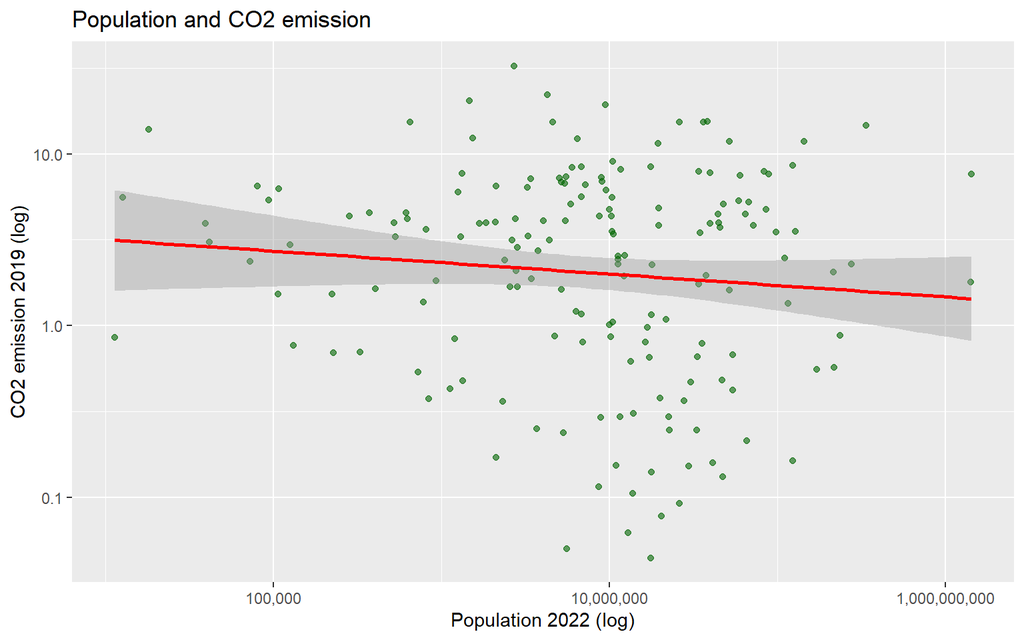

```r
# 1. Scatter plot (log scales because values are very spread out)
ggplot(merged, aes(Population_2022, CO2_2019)) +
  geom_point(alpha = .6, colour = "darkgreen") +
  geom_smooth(method = "lm", se = TRUE, colour = "red") +
  scale_x_log10(labels = label_comma()) +
  scale_y_log10(labels = label_comma()) +
  labs(x = "Population 2022 (log)", y = "CO2 emission 2019 (log)",
       title = "Population and CO2 emission")
```

```r
# 2. Correlation (numbers)
cor(merged$Population_2022, merged$CO2_2019, method = "pearson")
```

```
## [1] 0.01494215
```

```r
cor(merged$Population_2022, merged$CO2_2019, method = "spearman")
```

```
## [1] -0.08057256
```

```r
cor(log(merged$Population_2022), log(merged$CO2_2019))
```

```
## [1] -0.1010222
```

```r
# 3. Linear regression on the log scale
model <- lm(log(CO2_2019) ~ log(Population_2022), data = merged)
summary(model)
```

```
##
## Call:
## lm(formula = log(CO2_2019) ~ log(Population_2022), data = merged)
##
## Residuals:
##     Min      1Q  Median      3Q     Max
## -3.7648 -0.9682  0.3096  1.0304  2.6990
##
## Coefficients:
##                      Estimate Std. Error t value Pr(>|t|)
## (Intercept)           1.76733    0.79979   2.210   0.0285 *
## log(Population_2022) -0.06658    0.05014  -1.328   0.1860
## ---
## Signif. codes:  0 '***' 0.001 '**' 0.01 '*' 0.05 '.' 0.1 ' ' 1
##
## Residual standard error: 1.411 on 171 degrees of freedom
## Multiple R-squared:  0.01021,    Adjusted R-squared:  0.004417
## F-statistic: 1.763 on 1 and 171 DF,  p-value: 0.186
```

# 8. CO2 emissions by continent (2019)

```r
by_continent <- merged %>%
  group_by(Continent) %>%
  summarise(Total_CO2_2019 = sum(CO2_2019, na.rm = TRUE)) %>%
  arrange(desc(Total_CO2_2019))

by_continent
```

```
## # A tibble: 6 × 2
##   Continent     Total_CO2_2019
##   <chr>                  <dbl>
## 1 Asia                   266.
## 2 Europe                 241.
## 3 North America           79.6
## 4 Africa                  60.5
## 5 Oceania                 53.2
## 6 South America           29.4
```

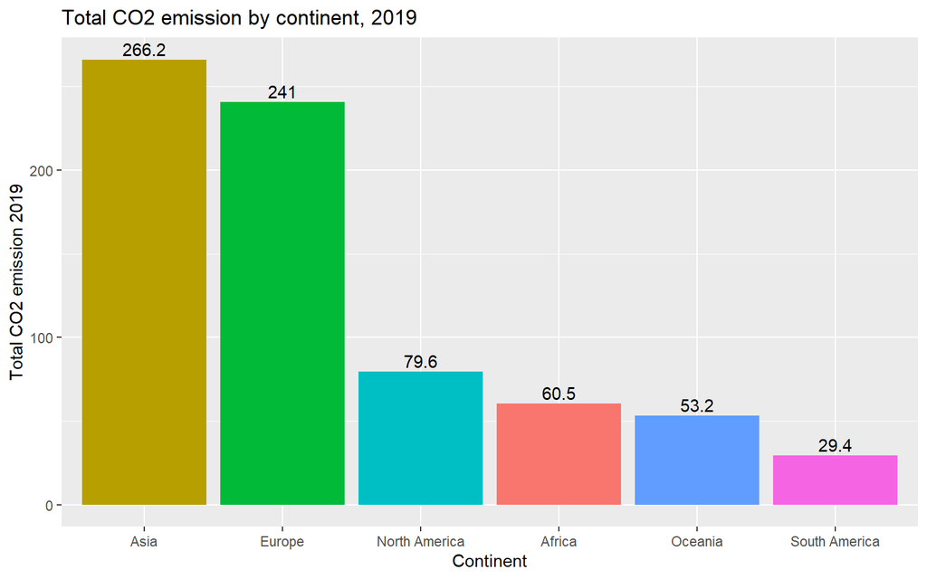

```r
ggplot(by_continent, aes(x = reorder(Continent, -Total_CO2_2019),
                         y = Total_CO2_2019, fill = Continent)) +
  geom_col(show.legend = FALSE) +
  geom_text(aes(label = round(Total_CO2_2019, 1)), vjust = -0.3) +
  labs(x = "Continent", y = "Total CO2 emission 2019",
       title = "Total CO2 emission by continent, 2019")
```

**Answers (printed automatically from the data):**

```r
r1 <- by_continent[1, ]
r3 <- by_continent[3, ]
rl <- by_continent[nrow(by_continent), ]

cat(sprintf("1. **First continent (highest 2019 CO2):** %s, total %.2f.\n\n",
            r1$Continent, r1$Total_CO2_2019))
```

1. **First continent (highest 2019 CO2):** Asia, total 266.18.

```r
cat(sprintf("2. **Third continent:** %s, total %.2f.\n\n",
            r3$Continent, r3$Total_CO2_2019))
```

2. **Third continent:** North America, total 79.57.

```r
cat(sprintf("3. **Last continent (lowest):** %s, total %.2f.\n\n",
            rl$Continent, rl$Total_CO2_2019))
```

3. **Last continent (lowest):** South America, total 29.42.

# 9. Conclusion